# Hello! Today...

- Quick talk about the midterm
- Regressions
  - Maybe finish up regression mechanics file with discussion (of my answer file)
  - **Copy the "Regression interpretation.ipynb" handout into your class notes folder.**

## Our first, real, farm-to-table analysis is complete and submitted!

I had some fun looking at data from GitHub as everyone's work progressed:

There was the usual rush at the finish, though students waited longer than ever to get going compare to prior years:

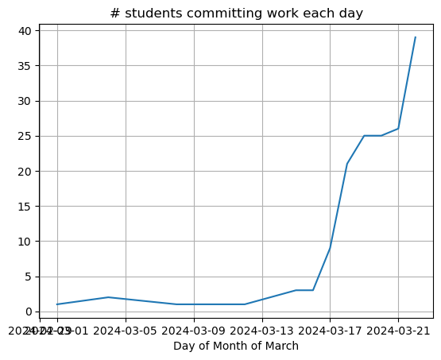

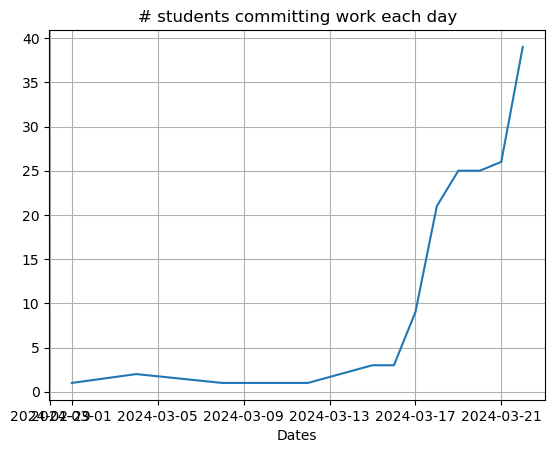

The median student had at least 14 commits (great!)

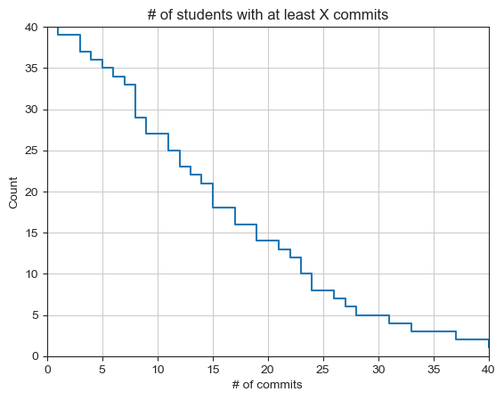

## CONGRATS!

[figure not shown]

## I'm **very grateful** for your effort

- I sincerely hope learning $\propto$ effort.
- [Midterm prompt](https://ledatascifi.github.io/ledatascifi-2024/content/assignments/mid_proj.html): "Cheers! ... Seriously: You are in the ball park of pulling off any analysis you want that needs to harness the power of these filings."

## Regression exercises

1. From the file last Wednesday:
   1. Check out how I graphed the data (usual issues with oversaturated plots), including fit lines
   2. Highly recommend: binsreg
   3. SKLEARN
2. Now: Copy the "Regression interpretation.ipynb" handout into your class notes folder.